# Tutorials for the WGCNA package

TigerZ

2022-10-25

下载tutorial数据： [zipped data sets](https://horvath.genetics.ucla.edu/html/CoexpressionNetwork/Rpackages/WGCNA/Tutorials/FemaleLiver-Data.zip)  
导入相关package：

```r
library(WGCNA)
```

# 1 Data input, cleaning and pre-processing

## 1.a Loading expression data

表达量数据包含在本教程附带的文件 LiverFemale3600.csv 中。

```r
# Read in the female liver data set
femData = read.csv("./FemaleLiver-Data/LiverFemale3600.csv")
# Take a quick look at what is in the data set:
dim(femData)
```

```
[1] 3600  143
```

行为gene，列为sample和其他信息，表达量数据集包含 135 个样本。

```r
head(femData)
```

|  | substanceBXH | gene_symbol | LocusLinkID | ProteomeID | cytogeneticLoc | CHROMOSOME | StartPosition | EndPosition | F2_2 | F2_3 | F2_14 | F2_15 | F2_19 | F2_20 | F2_23 | F2_24 | F2_26 | F2_37 | F2_42 | F2_43 | F2_45 | F2_46 | F2_47 | F2_48 | F2_51 | F2_52 | F2_54 | F2_63 | F2_65 | … |
| --- | --- | --- | --- | --- | --- | --- | --- | --- | --- | --- | --- | --- | --- | --- | --- | --- | --- | --- | --- | --- | --- | --- | --- | --- | --- | --- | --- | --- | --- | --- |
| 1 | MMT00000044 | 1700007N18Rik | 69339 | 286025 | 0 | 16 | 50911260 | 50912491 | -0.01810 | 0.0642 | 6.44e-05 | -0.05800 | 0.04830 | -0.15197410 | -0.00129 | -0.23600 | -0.0307 | -0.02610 | 0.073705890 | -0.0466 | -0.00673 | -0.0193 | 0.09040 | 0.0290 | 0.0356 | -0.0388 | -0.0360 | -0.05600 | 0.009840 | … |
| 2 | MMT00000046 | Mast2 | 17776 | 157466 | 0 | 4 | 115215318 | 115372404 | -0.07730 | -0.0297 | 1.12e-01 | -0.05890 | 0.04430 | -0.09380000 | 0.09340 | 0.02690 | -0.1330 | 0.07570 | -0.009193803 | -0.0075 | 0.01700 | 0.0722 | -0.08390 | 0.0273 | -0.0784 | -0.0178 | 0.1120 | 0.12300 | 0.051700 | … |
| 3 | MMT00000051 | Ankrd32 | 105377 | 321939 | 0 | 13 | 74940309 | 74982847 | -0.02260 | 0.0617 | -1.29e-01 | 0.08710 | -0.11500 | -0.06502607 | 0.00249 | -0.10200 | 0.1420 | -0.10200 | 0.064289290 | 0.0169 | -0.01590 | -0.1430 | -0.00492 | -0.0735 | 0.0657 | -0.0197 | -0.1290 | -0.14300 | -0.061600 | … |
| 4 | MMT00000076 | 0 | 383154 | 0 | 0 | 16 | 49345114 | 49477048 | -0.00924 | -0.1450 | 2.87e-02 | -0.04390 | 0.00425 | -0.23610000 | -0.06900 | 0.01440 | 0.0363 | -0.01820 | 0.477874600 | 0.1440 | 0.11100 | 0.0113 | 0.11900 | 0.0225 | 0.0932 | 0.1430 | 0.2640 | -0.09280 | -0.000635 | … |
| 5 | MMT00000080 | Ldb2 | 16826 | 157383 | 0 | 5 | 43546124 | 43613704 | -0.04870 | 0.0582 | -4.83e-02 | -0.03710 | 0.02510 | 0.08504274 | 0.04450 | 0.00167 | -0.0680 | 0.00567 | -0.075348680 | -0.0673 | -0.04720 | 0.0701 | -0.08790 | -0.0180 | -0.1290 | -0.0469 | -0.0352 | -0.00166 | 0.058700 | … |
| 6 | MMT00000102 | Rdhs | 216453 | 0 | 10_70.0_cM | 10 | 1337265 | 1347607 | 0.17600 | -0.1890 | -6.50e-02 | -0.00846 | -0.00574 | -0.01807182 | -0.12500 | -0.06820 | 0.1250 | 0.00998 | -0.037366600 | -0.0402 | -0.02190 | 0.0269 | 0.13300 | 0.0732 | 0.1070 | -0.0362 | -0.0696 | -0.19400 | -0.117000 | … |

我们现在删除辅助数据并转置表达数据以进行进一步分析： datExpr0 行为135个样本，列为3600个gene

```r
datExpr0 = as.data.frame(t(femData[, -c(1:8)]))
colnames(datExpr0) = femData$substanceBXH
rownames(datExpr0) = colnames(femData)[-c(1:8)]
dim(datExpr0)
```

```
[1]  135 3600
```

## 1.b 检查数据是否有过度的缺失值和识别离群值

我们首先检查缺失值过多的基因和样本：

```r
gsg = goodSamplesGenes(datExpr0, verbose = 3)
```

```
 Flagging genes and samples with too many missing values...
  ..step 1
```

```r
gsg$allOK
```

```
[1] TRUE
```

如果gsg$allOK的结果为TRUE，证明没有缺失值，可以直接下一步。如果为FALSE，则需要用以下函数进行删除缺失值。

```r
if (!gsg$allOK){
  # Optionally, print the gene and sample names that were removed:
  if (sum(!gsg$goodGenes)>0)
  printFlush(paste("Removing genes:", paste(names(datExpr0)[!gsg$goodGenes], collapse = ", ")));
  if (sum(!gsg$goodSamples)>0)
  printFlush(paste("Removing samples:", paste(rownames(datExpr0)[!gsg$goodSamples], collapse = ", ")));
  # Remove the offending genes and samples from the data:
  datExpr0 = datExpr0[gsg$goodSamples, gsg$goodGenes]
}
```

接下来我们对样本进行聚类,以查看是否有任何明显的异常值

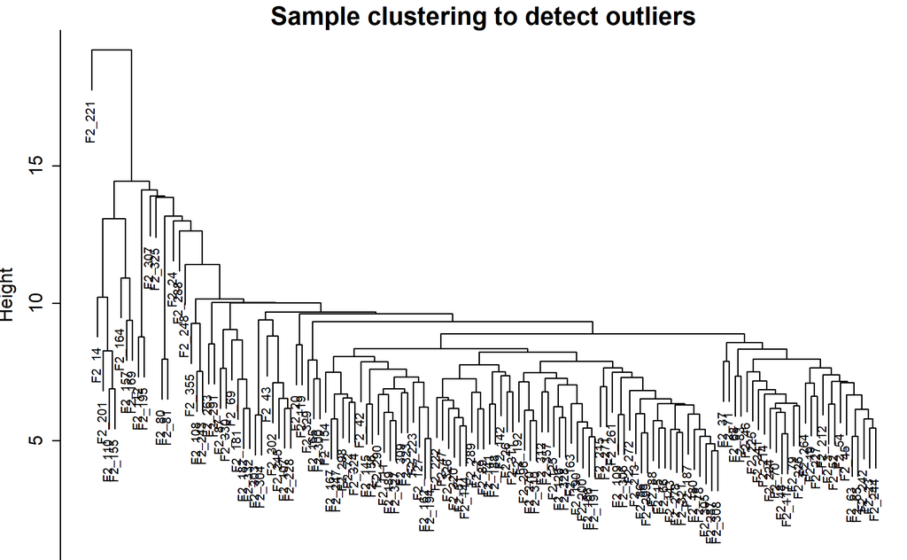

```r
sampleTree = hclust(dist(datExpr0), method = "average");
# Plot the sample tree: Open a graphic output window of size 12 by 9 inches
# The user should change the dimensions if the window is too large or too small.
sizeGrWindow(12,9)
#pdf(file = "Plots/sampleClustering.pdf", width = 12, height = 9);
par(cex = 0.6);
par(mar = c(0,4,2,0))
plot(sampleTree, main = "Sample clustering to detect outliers", sub="", xlab="",
     cex.lab = 1.5,cex.axis = 1.5, cex.main = 2)
```

如果有离群值，则要删去离群的样本，如果没有则跳过下一步。

```r
# Plot a line to show the cut
#abline(h = 15, col = "red");
# Determine cluster under the line
clust = cutreeStatic(sampleTree, cutHeight = 15, minSize = 10)
table(clust)
# clust 1 contains the samples we want to keep.
keepSamples = (clust==1)
datExpr = datExpr0[keepSamples, ]
nGenes = ncol(datExpr)
nSamples = nrow(datExpr)
```

## 1.c Loading clinical trait data

我们现在读入表型数据,并将它们与表达量样本匹配

```r
traitData = read.csv("./FemaleLiver-Data/ClinicalTraits.csv");
# remove columns that hold information we do not need.
allTraits = traitData[, -c(31, 16)];
allTraits = allTraits[, c(2, 11:36) ];
# Form a data frame analogous to expression data that will hold the clinical traits.
femaleSamples = rownames(datExpr);
traitRows = match(femaleSamples, allTraits$Mice)
datTraits = allTraits[traitRows, -1]
rownames(datTraits) = allTraits[traitRows, 1]
collectGarbage()
```

我们现在在变量 datExpr 中有表达量数据，在变量 datTraits 中有相应的表型数据。 在我们继续网络构建和模块检测之前，我们将表型与样本树状图的关系可视化。

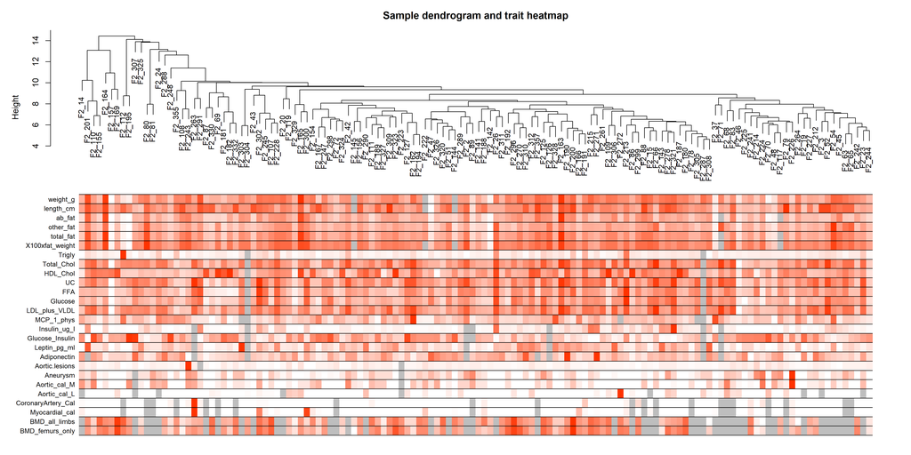

```r
# Re-cluster samples
sampleTree2 = hclust(dist(datExpr), method = "average")
# Convert traits to a color representation: white means low, red means high, grey means missing entry
traitColors = numbers2colors(datTraits, signed = FALSE);
# Plot the sample dendrogram and the colors underneath.
plotDendroAndColors(sampleTree2, traitColors, groupLabels = names(datTraits),
                    main = "Sample dendrogram and trait heatmap")
```

最后一步是保存相关的表达式和特征数据，以便在教程的后续步骤中使用。

```r
save(datExpr, datTraits, file = "FemaleLiver-01-dataInput.RData")
```

# 2 Automatic construction of the gene network and identification of modules

参数设置

```r
# 开启多线程
enableWGCNAThreads()
# 载入第一步保存的数据
lnames = load(file = "FemaleLiver-01-dataInput.RData");
lnames
```

## 2.a Automatic network construction and module detection

### 2.a.1 Choosing the soft-thresholding power: analysis of network topology

选择软阈值

```r
# Choose a set of soft-thresholding powers
powers = c(c(1:10), seq(from = 12, to=20, by=2))
# Call the network topology analysis function
sft = pickSoftThreshold(datExpr, powerVector = powers, verbose = 5)
```

```
pickSoftThreshold: will use block size 3600.
 pickSoftThreshold: calculating connectivity for given powers...
   ..working on genes 1 through 3600 of 3600
```

| Power | SFT.R.sq | slope | truncated.R.sq | mean.k. | median.k. | max.k. |
| --- | --- | --- | --- | --- | --- | --- |
| 1 | 0.0278 | 0.345 | 0.456 | 747.00 | 762.0000 | 1210.0 |
| 2 | 0.1260 | -0.597 | 0.843 | 254.00 | 251.0000 | 574.0 |
| 3 | 0.3400 | -1.030 | 0.972 | 111.00 | 102.0000 | 324.0 |
| 4 | 0.5060 | -1.420 | 0.973 | 56.50 | 47.2000 | 202.0 |
| 5 | 0.6810 | -1.720 | 0.940 | 32.20 | 25.1000 | 134.0 |
| 6 | 0.9020 | -1.500 | 0.962 | 19.90 | 14.5000 | 94.8 |
| 7 | 0.9210 | -1.670 | 0.917 | 13.20 | 8.6800 | 84.1 |
| 8 | 0.9040 | -1.720 | 0.876 | 9.25 | 5.3900 | 76.3 |
| 9 | 0.8590 | -1.700 | 0.836 | 6.80 | 3.5600 | 70.5 |
| 10 | 0.8330 | -1.660 | 0.831 | 5.19 | 2.3800 | 65.8 |

[output cut: 5 more lines]

```r
# Plot the results:
sizeGrWindow(9, 5)
par(mfrow = c(1,2))
cex1 = 0.9;
# Scale-free topology fit index as a function of the soft-thresholding power
plot(sft$fitIndices[,1], -sign(sft$fitIndices[,3])*sft$fitIndices[,2],
     xlab="Soft Threshold (power)", ylab="Scale Free Topology Model Fit,signed R^2",
     type="n", main = paste("Scale independence"));
text(sft$fitIndices[,1], -sign(sft$fitIndices[,3])*sft$fitIndices[,2],
     labels=powers,cex=cex1,col="red");
```

```r
# this line corresponds to using an R^2 cut-off of h
abline(h=0.90,col="red")
# Mean connectivity as a function of the soft-thresholding power
plot(sft$fitIndices[,1], sft$fitIndices[,5], xlab="Soft Threshold (power)",
     ylab="Mean Connectivity", type="n", main = paste("Mean connectivity"))
```

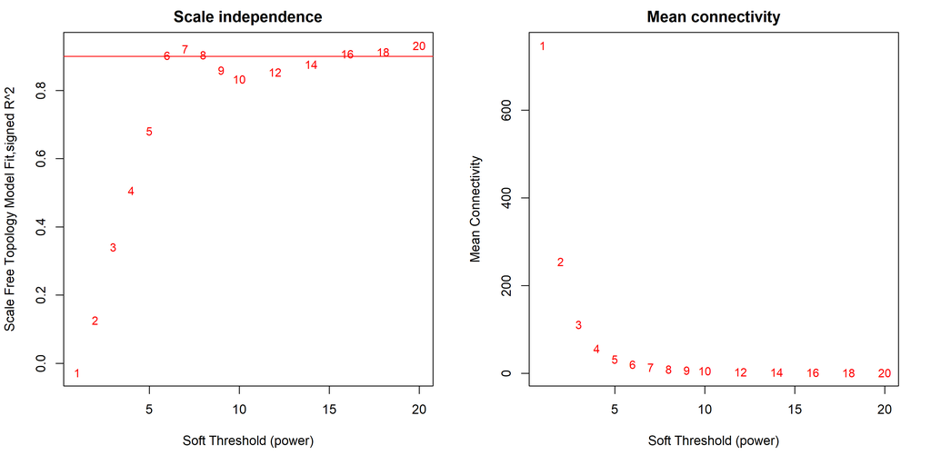

```r
text(sft$fitIndices[,1], sft$fitIndices[,5], labels=powers, cex=cex1,col="red")
```

左图，无标度拓扑拟合指数，是用来选择软阈值的一个根据。我们一般选择在0.9以上的， 第一个达到0.9以上数值。左图的6是第一个达到0.9的数值，可以考虑6作为软阈值。 如果在0.9以上就没有数值了，我们就要降低标准，但是最低不能小于0.8。  
右图，平均连接度，数值为6的时候，已经开始持平，则软阈值为6时，网络的连通性好。  
运行下面的代码，如果有合适的软阈值，系统会自动推荐给你:

```r
sft$powerEstimate
```

```
[1] 6
```

如果显示的结果为 NA，则表明系统无法给出合适的软阈值，这时候就需要自己挑选软阈值。 手动挑选软阈值的大致规则如上面所述。

### 2.a.2 One-step network construction and module detection

构建基因网络和识别模块现在是一个简单的函数调用：

```r
net = blockwiseModules(datExpr, power = 6, TOMType = "unsigned", minModuleSize = 30,
                       reassignThreshold = 0, mergeCutHeight = 0.25, numericLabels = TRUE,
                       pamRespectsDendro = FALSE, saveTOMs = TRUE,
                       saveTOMFileBase = "femaleMouseTOM", verbose = 3)
# 参数解释
# power = 6是刚才选择的软阈值
# minModuleSize：模块中最少的基因数
# mergeCutHeight：模块合并阈值，阈值越大，模块越少
# saveTOMs = TRUE,saveTOMFileBase = "femaleMouseTOM"保存TOM矩阵，名字为"femaleMouseTOM"
# net$colors 包含模块分配，net$MEs 包含模块的模块特征基因。
```

```r
table(net$colors)
```

```
  0   1   2   3   4   5   6   7   8   9  10  11  12  13  14  15  16  17  18
 99 609 460 409 316 312 221 211 157 123 106 100  94  91  77  76  58  47  34
```

以上结果表示一共可以分为18个模块，模块0是无法识别的基因,从模块1开始，基因数逐渐减少。

模块标识的层次聚类树状图，可以使用以下代码将树状图与颜色分配一起显示：

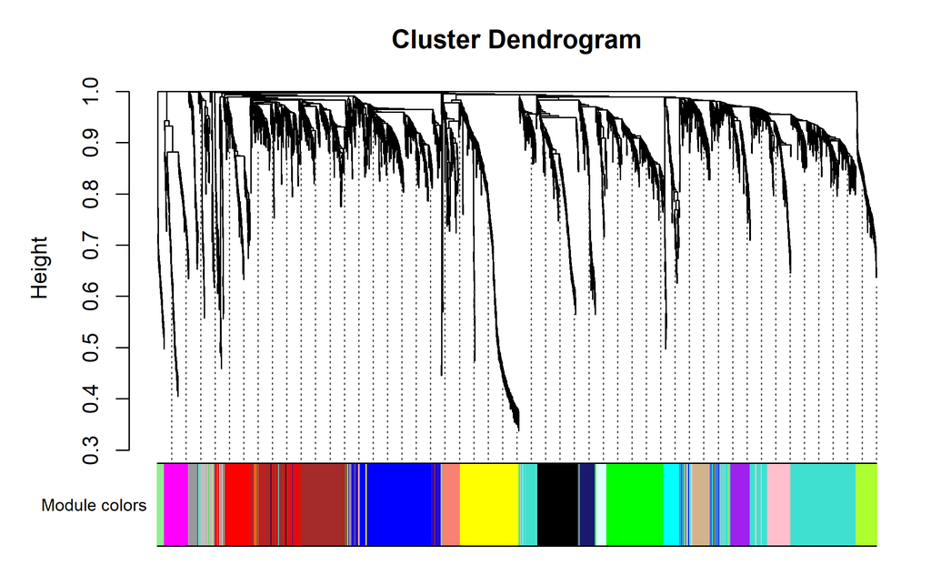

```r
sizeGrWindow(12, 9)
mergedColors = labels2colors(net$colors)
plotDendroAndColors(net$dendrograms[[1]], mergedColors[net$blockGenes[[1]]],
                    "Module colors",
                    dendroLabels = FALSE, hang = 0.03,
                    addGuide = TRUE, guideHang = 0.05)
```

如果需要修改树、模块成员、和模块合并标准，该包的recutBlockwiseTrees函数可以对结果进行修改，而无需重复计算网络和树状图。（推荐用第二种方法分步法实现）

保存分配模块和模块包含的基因信息。

```r
moduleLabels = net$colors
moduleColors = labels2colors(net$colors)
MEs = net$MEs;
geneTree = net$dendrograms[[1]];
save(MEs, moduleLabels, moduleColors, geneTree,
     file = "FemaleLiver-02-networkConstruction-auto.RData")
```

## 2.b Step-by-step network construction and module detection

导入前期数据

```r
lnames = load(file = "FemaleLiver-01-dataInput.RData");
lnames
```

```
[1] "datExpr"   "datTraits"
```

### 2.b.1 Choosing the soft-thresholding power: analysis of network topology

软阈值选择

```r
# Choose a set of soft-thresholding powers
powers = c(c(1:10), seq(from = 12, to=20, by=2))
# Call the network topology analysis function
sft = pickSoftThreshold(datExpr, powerVector = powers, verbose = 5)
```

```
pickSoftThreshold: will use block size 3600.
 pickSoftThreshold: calculating connectivity for given powers...
   ..working on genes 1 through 3600 of 3600
```

| Power | SFT.R.sq | slope | truncated.R.sq | mean.k. | median.k. | max.k. |
| --- | --- | --- | --- | --- | --- | --- |
| 1 | 0.0278 | 0.345 | 0.456 | 747.00 | 762.0000 | 1210.0 |
| 2 | 0.1260 | -0.597 | 0.843 | 254.00 | 251.0000 | 574.0 |
| 3 | 0.3400 | -1.030 | 0.972 | 111.00 | 102.0000 | 324.0 |
| 4 | 0.5060 | -1.420 | 0.973 | 56.50 | 47.2000 | 202.0 |
| 5 | 0.6810 | -1.720 | 0.940 | 32.20 | 25.1000 | 134.0 |
| 6 | 0.9020 | -1.500 | 0.962 | 19.90 | 14.5000 | 94.8 |
| 7 | 0.9210 | -1.670 | 0.917 | 13.20 | 8.6800 | 84.1 |
| 8 | 0.9040 | -1.720 | 0.876 | 9.25 | 5.3900 | 76.3 |
| 9 | 0.8590 | -1.700 | 0.836 | 6.80 | 3.5600 | 70.5 |
| 10 | 0.8330 | -1.660 | 0.831 | 5.19 | 2.3800 | 65.8 |

[output cut: 5 more lines]

```r
# Plot the results:
sizeGrWindow(9, 5)
par(mfrow = c(1,2));
cex1 = 0.9;
# Scale-free topology fit index as a function of the soft-thresholding power
plot(sft$fitIndices[,1], -sign(sft$fitIndices[,3])*sft$fitIndices[,2],
xlab="Soft Threshold (power)",ylab="Scale Free Topology Model Fit,signed R^2",type="n",
main = paste("Scale independence"));
text(sft$fitIndices[,1], -sign(sft$fitIndices[,3])*sft$fitIndices[,2],
labels=powers,cex=cex1,col="red");
```

```r
# this line corresponds to using an R^2 cut-off of h
abline(h=0.90,col="red")
# Mean connectivity as a function of the soft-thresholding power
plot(sft$fitIndices[,1], sft$fitIndices[,5],
xlab="Soft Threshold (power)",ylab="Mean Connectivity", type="n",
main = paste("Mean connectivity"))
```

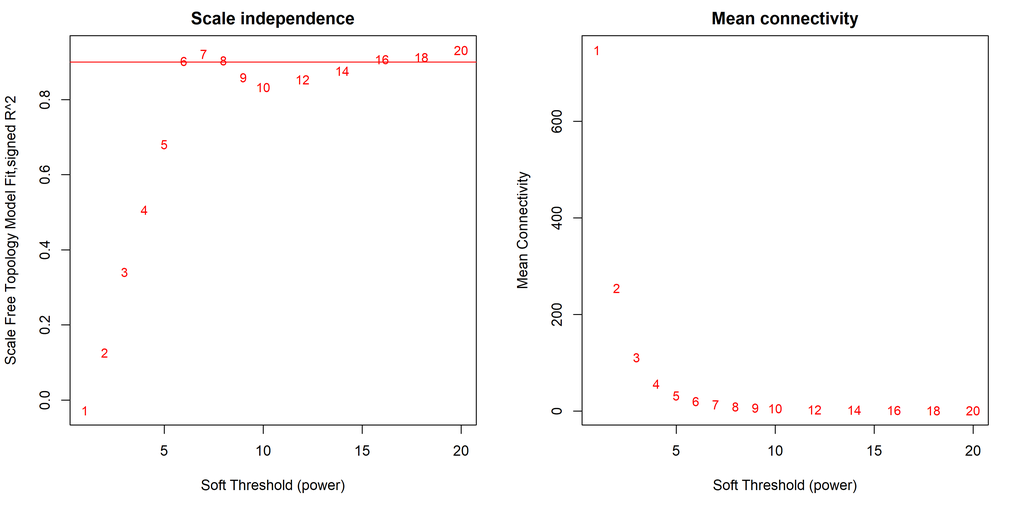

```r
text(sft$fitIndices[,1], sft$fitIndices[,5], labels=powers, cex=cex1,col="red")
```

## 2.b.2 Co-expression similarity and adjacency

```r
softPower = 6;
adjacency = adjacency(datExpr, power = softPower);
```

## 2.b.3 Topological Overlap Matrix (TOM)

```r
# Turn adjacency into topological overlap
TOM = TOMsimilarity(adjacency);
```

```
..connectivity..
..matrix multiplication (system BLAS)..
..normalization..
..done.
```

```r
dissTOM = 1-TOM
```

## 2.b.4 Clustering using TOM

我们现在使用层次聚类来产生一个基因的层次聚类树（树状图）。注意，我们使用了函数hclust，它提供了比标准hclust函数更快的层次聚类例程。

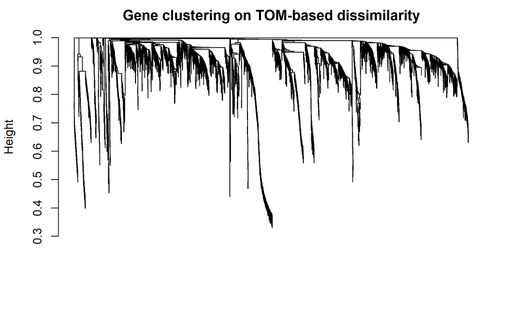

```r
# Call the hierarchical clustering function
geneTree = hclust(as.dist(dissTOM), method = "average");
# Plot the resulting clustering tree (dendrogram)
sizeGrWindow(12,9)
plot(geneTree, xlab="", sub="", main = "Gene clustering on TOM-based dissimilarity",
labels = FALSE, hang = 0.04);
```

在聚类树（树状图）中，每一片叶子，即一条短的垂直线，对应着一个基因。树状图的各个 分支聚集在一起，紧密相连，高度共表达的基因。模块识别相当于识别单个分支（“切断树状 图上的分支”）。分支切割有几种方法；我们的标准方法是使用 dynamicTreeCut 动态树切割。下一个代码片段说明了它的使用。

```r
# We like large modules, so we set the minimum module size relatively high:
minModuleSize = 30;
# Module identification using dynamic tree cut:
dynamicMods = cutreeDynamic(dendro = geneTree, distM = dissTOM, deepSplit = 2,
                            pamRespectsDendro=FALSE, minClusterSize=minModuleSize);
```

```
 ..cutHeight not given, setting it to 0.996  ===>  99% of the (truncated) height range in dendro.
 ..done.
```

```r
table(dynamicMods)
```

```
dynamicMods
  0   1   2   3   4   5   6   7   8   9  10  11  12  13  14  15  16  17  18  19
 88 614 316 311 257 235 225 212 158 153 121 106 102 100  94  91  78  76  65  58
 20  21  22
 58  48  34
```

该函数返回22个模块，标记为1-22个最大到最小。标签0被保留给未分配的基因。上面的命令列出了这些模块的大小。我们现在在基因树状图下绘制模块分配：

```r
# Convert numeric lables into colors
dynamicColors = labels2colors(dynamicMods)
table(dynamicColors)
```

```
dynamicColors
       black         blue        brown         cyan    darkgreen      darkred
         212          316          311           94           34           48
       green  greenyellow         grey       grey60    lightcyan   lightgreen
         235          106           88           76           78           65
 lightyellow      magenta midnightblue         pink       purple          red
          58          153           91          158          121          225
   royalblue       salmon          tan    turquoise       yellow
          58          100          102          614          257
```

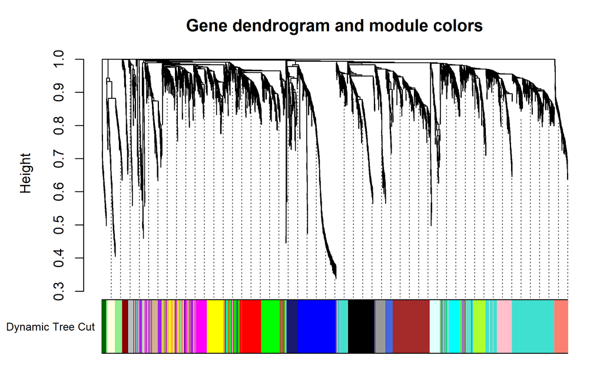

```r
# Plot the dendrogram and colors underneath
sizeGrWindow(8,6)
plotDendroAndColors(geneTree, dynamicColors, "Dynamic Tree Cut",
dendroLabels = FALSE, hang = 0.03,
addGuide = TRUE, guideHang = 0.05,
main = "Gene dendrogram and module colors")
```

## 2.b.5 Merging of modules whose expression profiles are very similar

动态树剪切可以识别其表达式配置文件非常相似的模块。合并这些模块可能是谨慎的， 因为它们的基因是高度共表达的。为了量化整个模块的共表达相似性，我们计算了它们的 特征基因，并对它们的相关性进行了聚类：

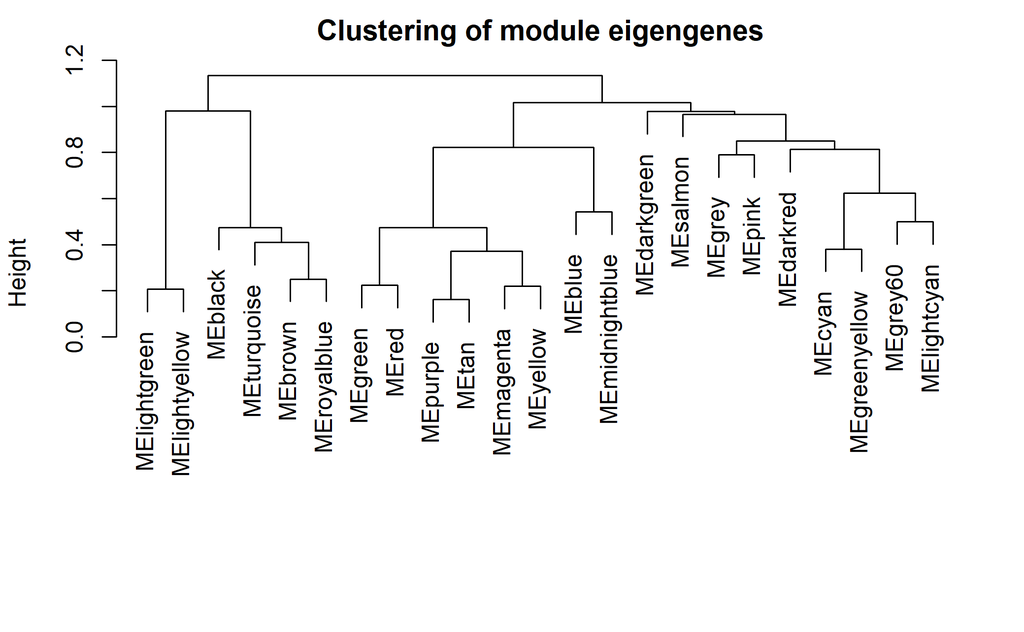

```r
# Calculate eigengenes
MEList = moduleEigengenes(datExpr, colors = dynamicColors)
MEs = MEList$eigengenes
# Calculate dissimilarity of module eigengenes
MEDiss = 1-cor(MEs);
# Cluster module eigengenes
METree = hclust(as.dist(MEDiss), method = "average");
# Plot the result
sizeGrWindow(7, 6)
plot(METree, main = "Clustering of module eigengenes", xlab = "", sub = "")
```

我们选择一个0.25的高度切割，对应的相关性为0.75，进行合并

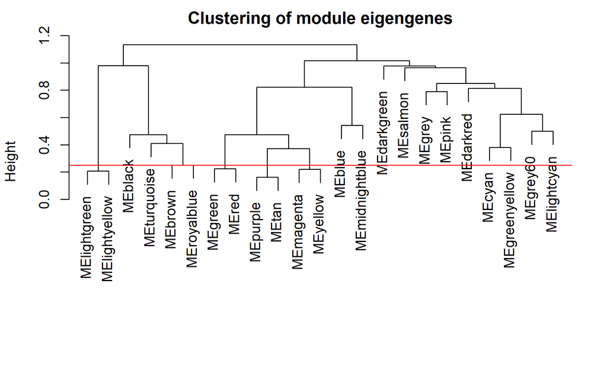

```r
plot(METree, main = "Clustering of module eigengenes", xlab = "", sub = "")
MEDissThres = 0.25
# Plot the cut line into the dendrogram
abline(h=MEDissThres, col = "red")
```

```r
# Call an automatic merging function
merge = mergeCloseModules(datExpr, dynamicColors, cutHeight = MEDissThres, verbose = 3)
```

```
 mergeCloseModules: Merging modules whose distance is less than 0.25
   multiSetMEs: Calculating module MEs.
     Working on set 1 ...
     moduleEigengenes: Calculating 23 module eigengenes in given set.
   multiSetMEs: Calculating module MEs.
     Working on set 1 ...
     moduleEigengenes: Calculating 19 module eigengenes in given set.
   Calculating new MEs...
   multiSetMEs: Calculating module MEs.
     Working on set 1 ...
     moduleEigengenes: Calculating 19 module eigengenes in given set.
```

```r
# The merged module colors
mergedColors = merge$colors;
# Eigengenes of the new merged modules:
mergedMEs = merge$newMEs;
```

为了了解合并对我们的模块颜色做了什么，我们再次绘制了基因树状图，下面是原始的和合 并的模块颜色

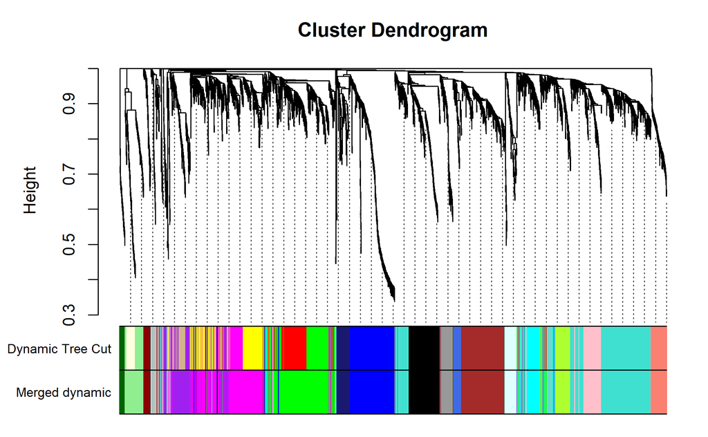

```r
sizeGrWindow(12, 9)
#pdf(file = "Plots/geneDendro-3.pdf", wi = 9, he = 6)
plotDendroAndColors(geneTree, cbind(dynamicColors, mergedColors),
c("Dynamic Tree Cut", "Merged dynamic"),
dendroLabels = FALSE, hang = 0.03,
addGuide = TRUE, guideHang = 0.05)
```

```r
#dev.off()
```

在随后的分析中，我们将在合并的颜色中使用合并的模块颜色。我们将相关变量保存在本教 程的后续部分中使用：

```r
# Rename to moduleColors
moduleColors = mergedColors
# Construct numerical labels corresponding to the colors
colorOrder = c("grey", standardColors(50));
moduleLabels = match(moduleColors, colorOrder)-1;
MEs = mergedMEs;
# Save module colors and labels for use in subsequent parts
save(MEs, moduleLabels, moduleColors, geneTree, file = "FemaleLiver-02-networkConstruction-stepByStep.RData")
```

# 3 Relating modules to external clinical traits

参数设置与载入之前的分析结果:

```r
load(file = "FemaleLiver-01-dataInput.RData");
load(file = "FemaleLiver-02-networkConstruction-auto.RData")
```

## 3.a Quantifying module–trait associations

在这项分析中，我们希望确定与测量的临床特征显著相关的模块。由于我们已经为每个模块 有了一个概要文件（特征基因），我们只是简单地将特征基因与外部特征联系起来，并寻找 最重要的关联：

```r
# Define numbers of genes and samples
nGenes = ncol(datExpr);
nSamples = nrow(datExpr);
# Recalculate MEs with color labels
MEs0 = moduleEigengenes(datExpr, moduleColors)$eigengenes
MEs = orderMEs(MEs0)
moduleTraitCor = cor(MEs, datTraits, use = "p");
moduleTraitPvalue = corPvalueStudent(moduleTraitCor, nSamples);
```

由于我们有相当数量的模块和特征，一个合适的图形表示将有助于读取表。我们用相关值为 每个关联进行颜色编码：

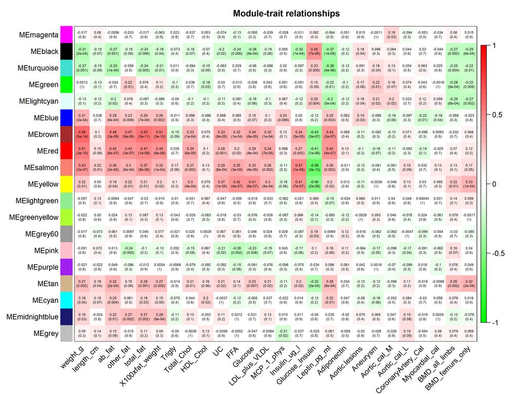

```r
sizeGrWindow(10,6)
# 展示模块与表型数据的相关系数和 P值
textMatrix = paste(signif(moduleTraitCor, 2), "\n(",
                   signif(moduleTraitPvalue, 1), ")", sep = "");
dim(textMatrix) = dim(moduleTraitCor)
par(mar = c(6, 8.5, 3, 3));
# 用热图的形式展示相关系数
labeledHeatmap(Matrix = moduleTraitCor,
               xLabels = names(datTraits),
               yLabels = names(MEs),
               ySymbols = names(MEs),
               colorLabels = FALSE,
               colors = greenWhiteRed(50),
               textMatrix = textMatrix,
               setStdMargins = FALSE,
               cex.text = 0.5,
               zlim = c(-1,1),
               main = paste("Module-trait relationships"))
```

```r
#colors = greenWhiteRed(50)不适用于红绿色盲患者，建议用 blueWhiteRed代替.
#该分析确定了几个重要的模块-特征关联。我们将体重作为感兴趣的特征来研究。
```

该分析确定了几个重要的模块-特征关联。我们将集中精力体重作为兴趣的特征。

## 3.b Gene relationship to trait and important modules: Gene Significance and Module Membership

我们通过定义 Gene Significance(GS) 为 gene 和 trait 的相关性，来量化单个基因与我们感兴趣的性状（体重weight）的关联。对于每个模块，我们定义 module membership(MM) 为 module eigengene 和 gene expression profile 的相关性。这使得我们能够量化阵列上的所有基因与每个模块的相似性。

```r
# Define variable weight containing the weight column of datTrait
weight = as.data.frame(datTraits$weight_g);
names(weight) = "weight"
# names (colors) of the modules
modNames = substring(names(MEs), 3)
geneModuleMembership = as.data.frame(cor(datExpr, MEs, use = "p"));
MMPvalue = as.data.frame(corPvalueStudent(as.matrix(geneModuleMembership), nSamples));
names(geneModuleMembership) = paste("MM", modNames, sep="");
names(MMPvalue) = paste("p.MM", modNames, sep="");
geneTraitSignificance = as.data.frame(cor(datExpr, weight, use = "p"));
GSPvalue = as.data.frame(corPvalueStudent(as.matrix(geneTraitSignificance), nSamples));
names(geneTraitSignificance) = paste("GS.", names(weight), sep="");
names(GSPvalue) = paste("p.GS.", names(weight), sep="");
```

## 3.c Intramodular analysis: identifying genes with high GS and MM

使用GS和MM测量方法，我们可以识别出对于 weight 有高显著性，并在感兴趣的模块中具有高模块成员身份的基因。作为一个例子，我们来看看与体重关联最高的棕色模块。

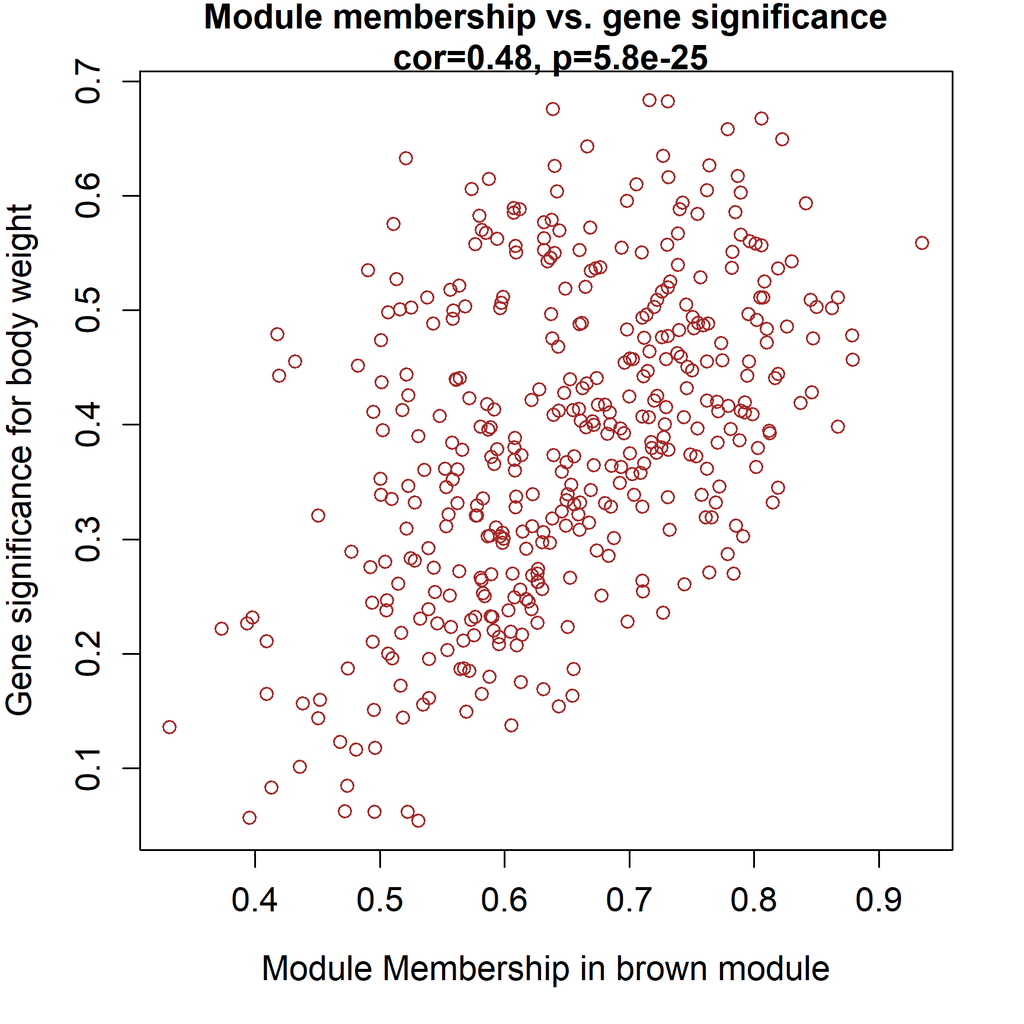

```r
module = "brown"
column = match(module, modNames);
moduleGenes = moduleColors==module;
sizeGrWindow(7, 7);
par(mfrow = c(1,1));
verboseScatterplot(abs(geneModuleMembership[moduleGenes, column]),
                   abs(geneTraitSignificance[moduleGenes, 1]),
                   xlab = paste("Module Membership in", module, "module"),
                   ylab = "Gene significance for body weight",
                   main = paste("Module membership vs. gene significance\n"),
                   cex.main = 1.2, cex.lab = 1.2, cex.axis = 1.2, col = module)
```

如上图所示。显然，GS和MM是高度相关的，这说明与一个性状高度显著相关的基因通常也是 与该性状相关的模块中最重要的（中心）元素。我们鼓励读者尝试这个具有其他显著性特征/模块相关性的代码（例如，洋红色、午夜蓝色和红色模块的重量）。

## 3.d Summary output of network analysis results

我们已经发现了与我们感兴趣的特征有高度相关的模块，并通过模块成员度度量确定了它们 的核心参与者。我们现在将这些统计信息与基因注释合并，并写出一个总结最重要结果的文件， 可以在标准电子表格软件如MS Excel或Open Office Calc中进行检查。 我们的表达量数据只用探针ID名称进行注释：命令

```r
#names(datExpr)#会返回所有在分析中的基因ID
#names(datExpr)[moduleColors=="brown"]#返回属于棕色模块的基因ID
annot = read.csv(file = "./FemaleLiver-Data/GeneAnnotation.csv");
dim(annot)
names(annot)
probes = names(datExpr) # 匹配信息
probes2annot = match(probes, annot$substanceBXH);
sum(is.na(probes2annot)) # 检测是否有没有匹配上的ID号，正常来说为0，即全匹配上了。输出必要的信息：
geneInfo0 = data.frame(substanceBXH = probes,
                       geneSymbol = annot$gene_symbol[probes2annot],
                       LocusLinkID = annot$LocusLinkID[probes2annot],
                       moduleColor = moduleColors,
                       geneTraitSignificance,
                       GSPvalue);
 #按照与体重的显著水平将模块进行排序:
 modOrder = order(-abs(cor(MEs, weight, use = "p")));
 #添加模块成员的信息：
 for (mod in 1:ncol(geneModuleMembership))
{
  oldNames = names(geneInfo0)
  geneInfo0 = data.frame(geneInfo0, geneModuleMembership[, modOrder[mod]],
                         MMPvalue[, modOrder[mod]]);
  names(geneInfo0) = c(oldNames, paste("MM.", modNames[modOrder[mod]], sep=""),
                       paste("p.MM.", modNames[modOrder[mod]], sep=""))
}
geneOrder = order(geneInfo0$moduleColor, -abs(geneInfo0$GS.weight));  # 排序
geneInfo = geneInfo0[geneOrder, ]
#输出为CSV格式，可用fix(geneInfo)在R中查看：
write.csv(geneInfo, file = "geneInfo.csv")
```